# Laboratorio n°6

Oscar Centeno Mora

Tomorrow never dies

# Redes Neuronales Artificiales en las series de tiempo

## Estimación de una RNA normal

El ejemplo se obtienen de https://www.r-bloggers.com/fitting-a-neural-network-in-r-neuralnet-package/

Obtengamos los datos

```r
set.seed(500)
library(MASS)
data <- Boston

apply(data,2,function(x) sum(is.na(x)))
```

```
##    crim      zn   indus    chas     nox      rm     age     dis     rad
##       0       0       0       0       0       0       0       0       0
##     tax ptratio   black   lstat    medv
##       0       0       0       0       0
```

Partición de la data

```r
index <- sample(1:nrow(data),round(0.75*nrow(data)))
train <- data[index,]
test <- data[-index,]
lm.fit <- glm(medv~., data=train)
summary(lm.fit)
```

```
##
## Call:
## glm(formula = medv ~ ., data = train)
##
## Deviance Residuals:
##      Min        1Q    Median        3Q       Max
## -14.9143   -2.8607   -0.5244    1.5242   25.0004
##
## Coefficients:
##               Estimate Std. Error t value Pr(>|t|)
## (Intercept)  43.469681   6.099347   7.127 5.50e-12 ***
## crim         -0.105439   0.057095  -1.847 0.065596 .
## zn            0.044347   0.015974   2.776 0.005782 **
## indus         0.024034   0.071107   0.338 0.735556
## chas          2.596028   1.089369   2.383 0.017679 *
## nox         -22.336623   4.572254  -4.885 1.55e-06 ***
## rm            3.538957   0.472374   7.492 5.15e-13 ***
## age           0.016976   0.015088   1.125 0.261291
## dis          -1.570970   0.235280  -6.677 9.07e-11 ***
## rad           0.400502   0.085475   4.686 3.94e-06 ***
## tax          -0.015165   0.004599  -3.297 0.001072 **
## ptratio      -1.147046   0.155702  -7.367 1.17e-12 ***
## black         0.010338   0.003077   3.360 0.000862 ***
## lstat        -0.524957   0.056899  -9.226  < 2e-16 ***
## ---
## Signif. codes:  0 '***' 0.001 '**' 0.01 '*' 0.05 '.' 0.1 ' ' 1
##
## (Dispersion parameter for gaussian family taken to be 23.26491)
##
##     Null deviance: 33642  on 379  degrees of freedom
## Residual deviance:  8515  on 366  degrees of freedom
## AIC: 2290
##
## Number of Fisher Scoring iterations: 2
```

```r
pr.lm <- predict(lm.fit,test)
MSE.lm <- sum((pr.lm - test$medv)^2)/nrow(test)
```

Preparación de la serie : escalamientos y asignación de los sets de entrenamiento y prueba

```r
maxs <- apply(data, 2, max)
mins <- apply(data, 2, min)

scaled <- as.data.frame(scale(data, center = mins, scale = maxs - mins))

train_ <- scaled[index,]
test_ <- scaled[-index,]
```

Estimación de la serie

```r
library(neuralnet)
n <- names(train_)
f <- as.formula(paste("medv ~", paste(n[!n %in% "medv"], collapse = " + ")))
nn <- neuralnet(f,data=train_,hidden=c(5,3),linear.output=T)
```

Visualización de la serie

```r
plot(nn)
```

[output not shown]

Predicción

```r
pr.nn <- compute(nn,test_[,1:13])

pr.nn_ <- pr.nn$net.result*(max(data$medv)-min(data$medv))+min(data$medv)
test.r <- (test_$medv)*(max(data$medv)-min(data$medv))+min(data$medv)

MSE.nn <- sum((test.r - pr.nn_)^2)/nrow(test_)

print(paste(MSE.lm,MSE.nn))
```

```
## [1] "21.6297593507225 15.7518370200153"
```

Validación interna

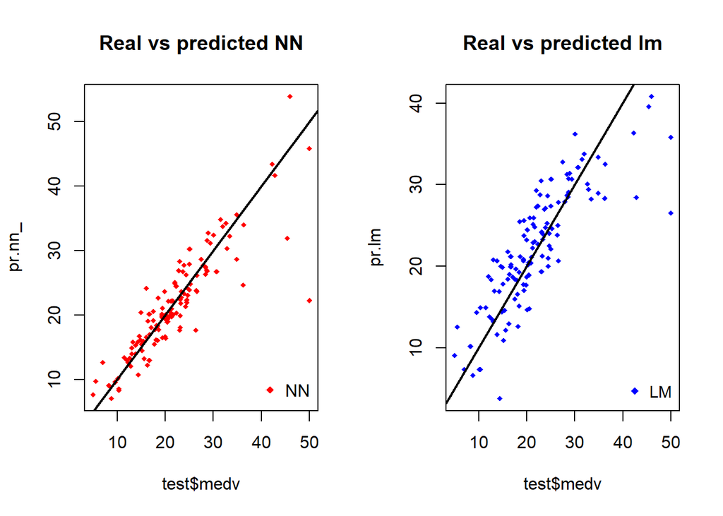

```r
par(mfrow=c(1,2))

plot(test$medv,pr.nn_,col='red',main='Real vs predicted NN',pch=18,cex=0.7)
abline(0,1,lwd=2)
legend('bottomright',legend='NN',pch=18,col='red', bty='n')

plot(test$medv,pr.lm,col='blue',main='Real vs predicted lm',pch=18, cex=0.7)
abline(0,1,lwd=2)
legend('bottomright',legend='LM',pch=18,col='blue', bty='n', cex=.95)
```

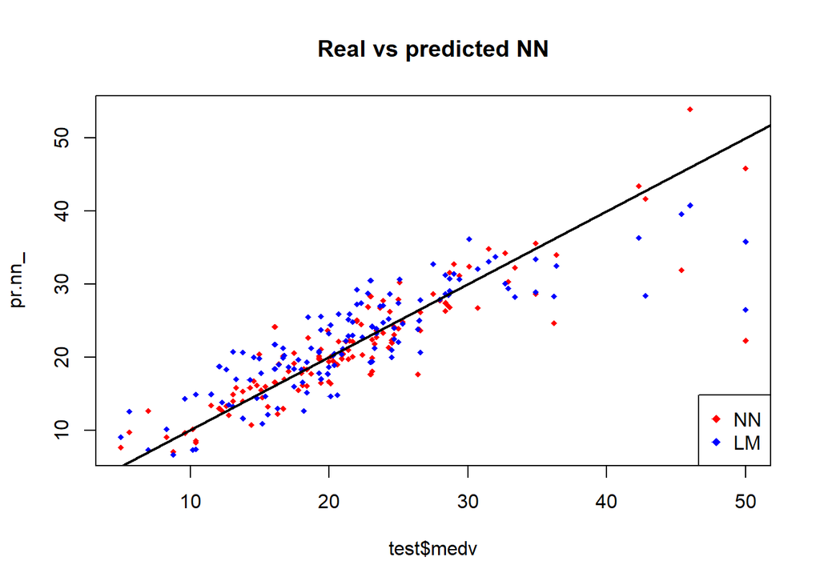

```r
par(mfrow=c(1,1))

plot(test$medv,pr.nn_,col='red',main='Real vs predicted NN',pch=18,cex=0.7)
points(test$medv,pr.lm,col='blue',pch=18,cex=0.7)
abline(0,1,lwd=2)
legend('bottomright',legend=c('NN','LM'),pch=18,col=c('red','blue'))
```

## Regresión mediante una RNA

### Regresión con una capa

Datos

```r
Yacht_Data <- read_table(file = 'http://archive.ics.uci.edu/ml/machine-learning-databases/00243/yacht_hydrodynamics.data',
                         col_names = c('LongPos_COB', 'Prismatic_Coeff',
                                       'Len_Disp_Ratio', 'Beam_Draut_Ratio',
                                       'Length_Beam_Ratio','Froude_Num',
                                       'Residuary_Resist')) %>%
  na.omit()
```

Correlaciones

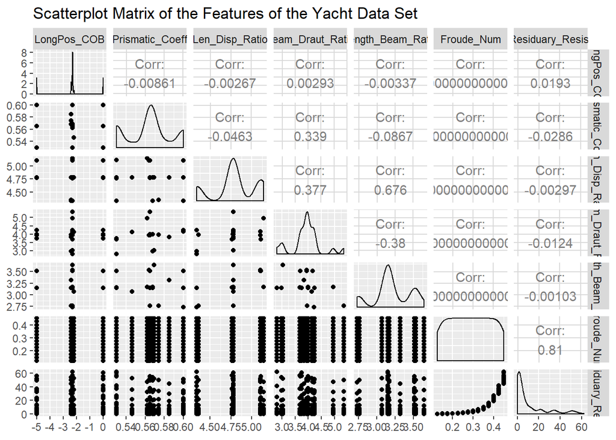

```r
ggpairs(Yacht_Data, title = "Scatterplot Matrix of the Features of the Yacht Data Set")
```

Partición de los datos

```r
scale01 <- function(x){
  (x - min(x)) / (max(x) - min(x))
}
Yacht_Data <- Yacht_Data %>%
  mutate_all(scale01)

set.seed(12345)
Yacht_Data_Train <- sample_frac(tbl = Yacht_Data, replace = FALSE, size = 0.80)
Yacht_Data_Test <- anti_join(Yacht_Data, Yacht_Data_Train)
```

Regresión con una sola capa oculta

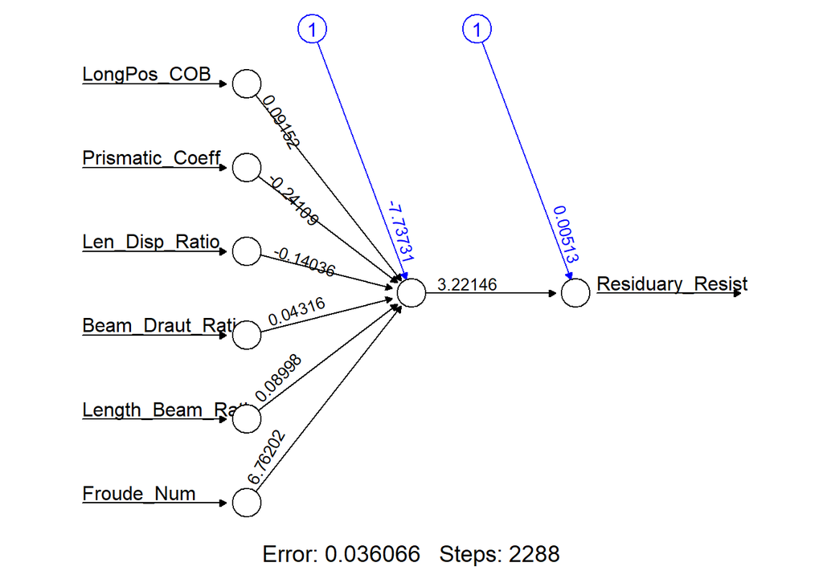

```r
set.seed(12321)
Yacht_NN1 <- neuralnet(Residuary_Resist ~ LongPos_COB + Prismatic_Coeff +
                         Len_Disp_Ratio + Beam_Draut_Ratio + Length_Beam_Ratio +
                         Froude_Num, data = Yacht_Data_Train)


plot(Yacht_NN1, rep = 'best')
```

Una medida de rendimiento

```r
NN1_Train_SSE <- sum((Yacht_NN1$net.result - Yacht_Data_Train[, 7])^2)/2
paste("SSE: ", round(NN1_Train_SSE, 4))
```

```
## [1] "SSE:  0.0361"
```

Validación

```r
Test_NN1_Output <- compute(Yacht_NN1, Yacht_Data_Test[, 1:6])$net.result
NN1_Test_SSE <- sum((Test_NN1_Output - Yacht_Data_Test[, 7])^2)/2
NN1_Test_SSE
```

```
## [1] 0.008417631461
```

### Regresión con hyper parámetros : diversas capas

Veamos ahora con dos capas ocultas: 2-Hidden Layers, Layer-1 4-neurons, Layer-2, 1-neuron, logistic activation

```r
set.seed(12321)
Yacht_NN2 <- neuralnet(Residuary_Resist ~ LongPos_COB + Prismatic_Coeff + Len_Disp_Ratio +
                         Beam_Draut_Ratio + Length_Beam_Ratio + Froude_Num, data = Yacht_Data_Train,
                       hidden = c(4, 1), act.fct = "logistic")
```

Error de entrenamiento

```r
NN2_Train_SSE <- sum((Yacht_NN2$net.result - Yacht_Data_Train[, 7])^2)/2
```

Error de validación

```r
Test_NN2_Output <- compute(Yacht_NN2, Yacht_Data_Test[, 1:6])$net.result
NN2_Test_SSE <- sum((Test_NN2_Output - Yacht_Data_Test[, 7])^2)/2
```

Re escalamiento

```r
scale11 <- function(x) {
  (2 * ((x - min(x))/(max(x) - min(x)))) - 1
}
Yacht_Data_Train <- Yacht_Data_Train %>% mutate_all(scale11)
Yacht_Data_Test <- Yacht_Data_Test %>% mutate_all(scale11)
```

Y otras cosas, vamos al grano…

```r
# 2-Hidden Layers, Layer-1 4-neurons, Layer-2, 1-neuron, tanh activation
# function
set.seed(12321)
Yacht_NN3 <- neuralnet(Residuary_Resist ~ LongPos_COB + Prismatic_Coeff + Len_Disp_Ratio +
                         Beam_Draut_Ratio + Length_Beam_Ratio + Froude_Num, data = Yacht_Data_Train,
                       hidden = c(4, 1), act.fct = "tanh")
## Training Error
NN3_Train_SSE <- sum((Yacht_NN3$net.result - Yacht_Data_Train[, 7])^2)/2
## Test Error
Test_NN3_Output <- compute(Yacht_NN3, Yacht_Data_Test[, 1:6])$net.result
NN3_Test_SSE <- sum((Test_NN3_Output - Yacht_Data_Test[, 7])^2)/2

# 1-Hidden Layer, 1-neuron, tanh activation function
set.seed(12321)
Yacht_NN4 <- neuralnet(Residuary_Resist ~ LongPos_COB + Prismatic_Coeff + Len_Disp_Ratio +
                         Beam_Draut_Ratio + Length_Beam_Ratio + Froude_Num, data = Yacht_Data_Train,
                       act.fct = "tanh")
## Training Error
NN4_Train_SSE <- sum((Yacht_NN4$net.result - Yacht_Data_Train[, 7])^2)/2
## Test Error
Test_NN4_Output <- compute(Yacht_NN4, Yacht_Data_Test[, 1:6])$net.result
NN4_Test_SSE <- sum((Test_NN4_Output - Yacht_Data_Test[, 7])^2)/2
```

Resultados de cuántas capas deberíamos tomar

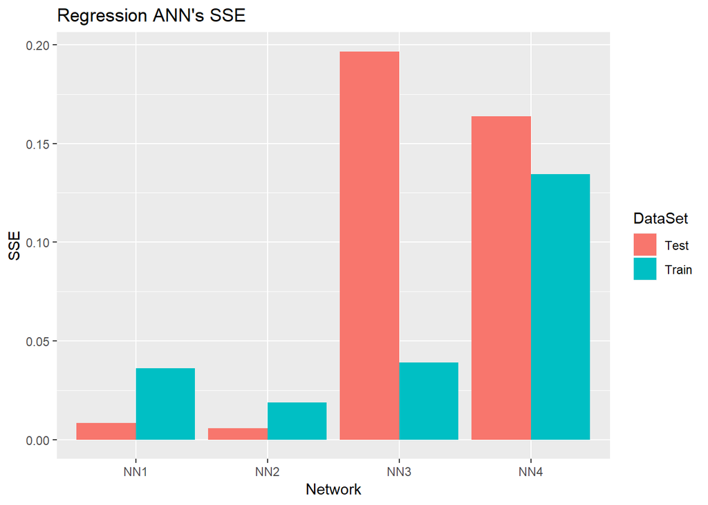

```r
Regression_NN_Errors <- tibble(Network = rep(c("NN1", "NN2", "NN3", "NN4"),
                                             each = 2), DataSet = rep(c("Train", "Test"), time = 4), SSE = c(NN1_Train_SSE,
                                                                                                             NN1_Test_SSE, NN2_Train_SSE, NN2_Test_SSE, NN3_Train_SSE, NN3_Test_SSE,
                                                                                                             NN4_Train_SSE, NN4_Test_SSE))
Regression_NN_Errors %>% ggplot(aes(Network, SSE, fill = DataSet)) + geom_col(position = "dodge") +
  ggtitle("Regression ANN's SSE")
```

Veamos la red con la función de impulso y sus pesos

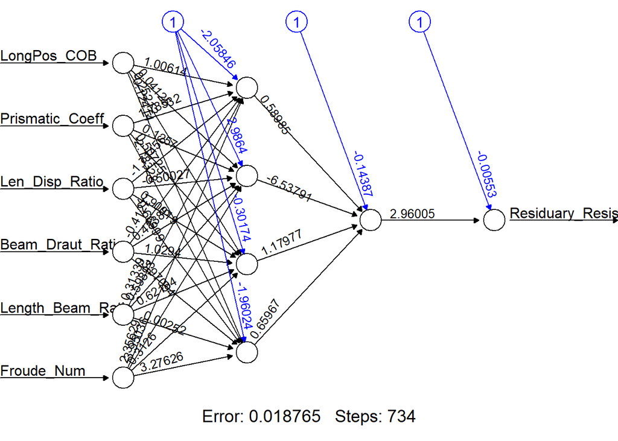

```r
plot(Yacht_NN2, rep = "best")
```

Veamos la RNA con una función de activación tangente

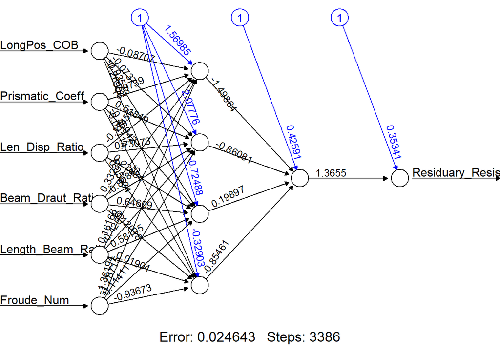

```r
set.seed(12321)
Yacht_NN2 <- neuralnet(Residuary_Resist ~ LongPos_COB + Prismatic_Coeff + Len_Disp_Ratio +
                         Beam_Draut_Ratio + Length_Beam_Ratio + Froude_Num, data = Yacht_Data_Train,
                       hidden = c(4, 1), act.fct = "tanh", rep = 10)
plot(Yacht_NN2, rep = "best")
```

## Resultados

### Serie sunspotarea

Pronóstico sin intervalos de confianza

```r
fit <- nnetar(sunspotarea, lambda=0)
(fit <- nnetar(sunspotarea, lambda=0))
```

```
## Series: sunspotarea
## Model:  NNAR(10,6)
## Call:   nnetar(y = sunspotarea, lambda = 0)
##
## Average of 20 networks, each of which is
## a 10-6-1 network with 73 weights
## options were - linear output units
##
## sigma^2 estimated as 0.057419
```

```r
summary(fit)
```

```
##           Length Class        Mode
## x         141    ts           numeric
## m           1    -none-       numeric
## p           1    -none-       numeric
## P           1    -none-       numeric
## scalex      2    -none-       list
## size        1    -none-       numeric
## lambda      1    -none-       numeric
## subset    141    -none-       numeric
## model      20    nnetarmodels list
## nnetargs    0    -none-       list
## fitted    141    ts           numeric
## residuals 141    ts           numeric
## lags       10    -none-       numeric
## series      1    -none-       character
## method      1    -none-       character
## call        3    -none-       call
```

```r
(fit <- nnetar(lynx, lambda=0.5))
```

```
## Series: lynx
## Model:  NNAR(8,4)
## Call:   nnetar(y = lynx, lambda = 0.5)
##
## Average of 20 networks, each of which is
## a 8-4-1 network with 41 weights
## options were - linear output units
##
## sigma^2 estimated as 99.37944
```

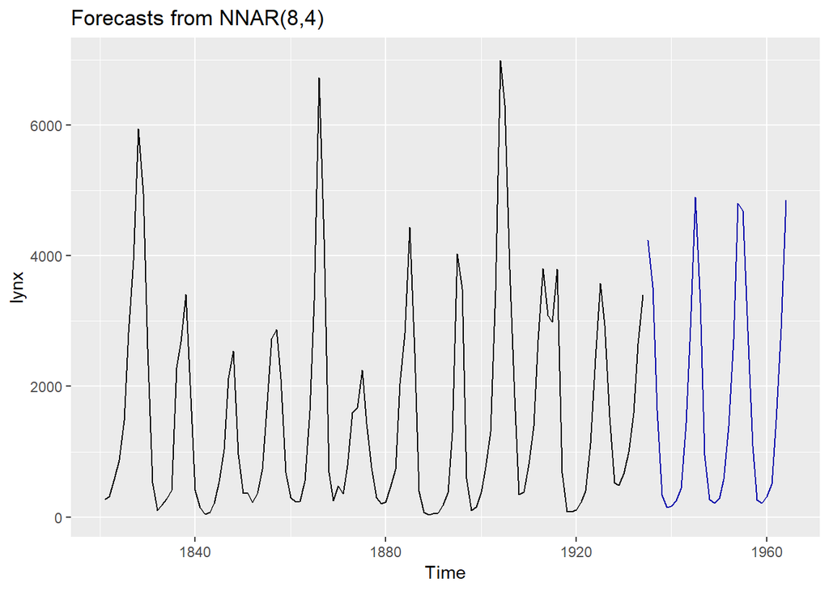

```r
autoplot(forecast(fit,h=30))
```

Pronóstico con intervalos de confianza

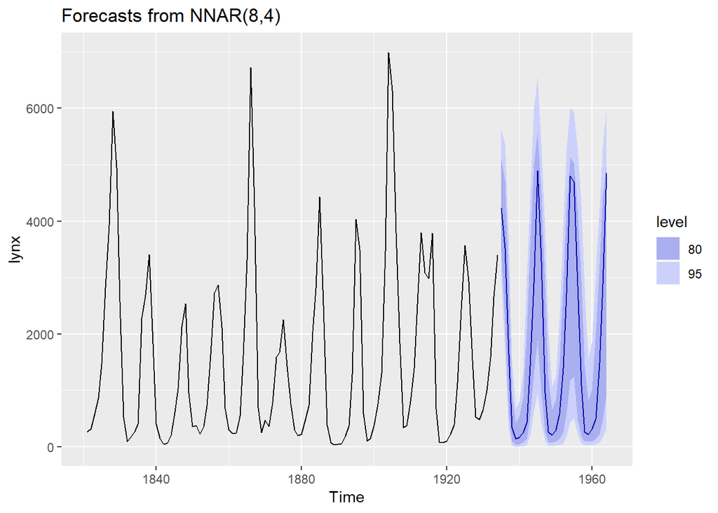

```r
fcast <- forecast(fit, PI=TRUE, h=30)
autoplot(fcast)
```

### Serie oil

Vamos a utilizar sobre el petroleo

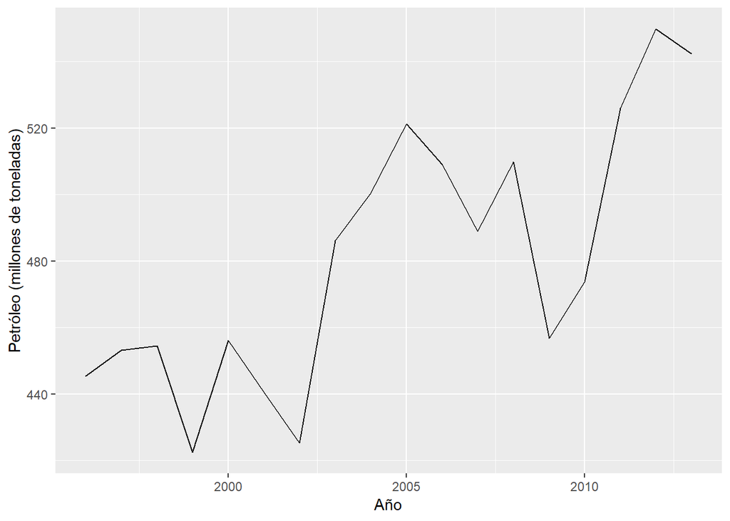

```r
oildata <- window(oil, start=1996)
autoplot(oildata) +  ylab("Petróleo (millones de toneladas)") + xlab("Año")
```

Estimación del modelo por NNA

```r
mod.1 <- nnetar(oildata, lambda=0)
(mod.1 <- nnetar(oildata, lambda=0))
```

```
## Series: oildata
## Model:  NNAR(1,1)
## Call:   nnetar(y = oildata, lambda = 0)
##
## Average of 20 networks, each of which is
## a 1-1-1 network with 4 weights
## options were - linear output units
##
## sigma^2 estimated as 0.002440033
```

Visualización de los valores observador y ajustados

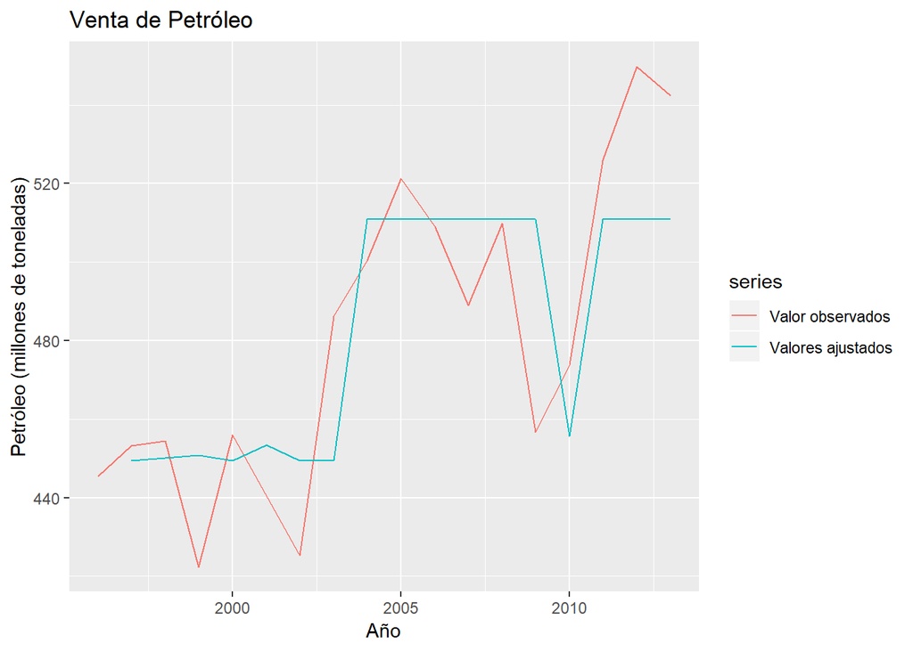

```r
autoplot(oildata, series="Valor observados") +
  autolayer(fitted(mod.1), series="Valores ajustados") +
  ylab("Petróleo (millones de toneladas)") + xlab("Año") +
  ggtitle("Venta de Petróleo ")
```

Estadísticas de rendimiento

```r
round(accuracy(mod.1),2)
```

```
##                ME  RMSE   MAE   MPE MAPE MASE  ACF1
## Training set 0.55 23.88 18.87 -0.13 3.93 0.78 -0.02
```

Valores pronosticados con intervalo de confianza

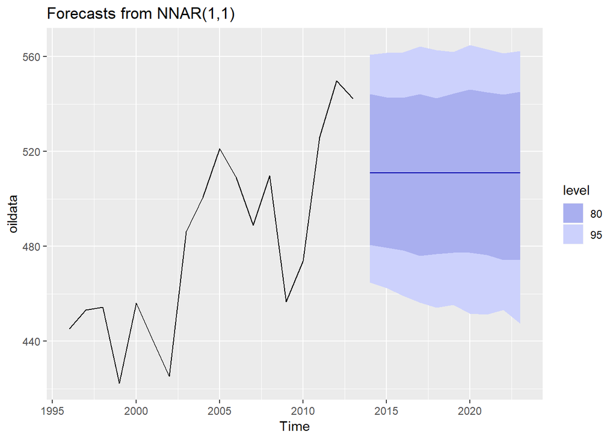

```r
fcast.1 <- forecast(mod.1, PI=TRUE, h=10)

autoplot(fcast.1)
```

Valores pronosticados sin intervalo de confianza

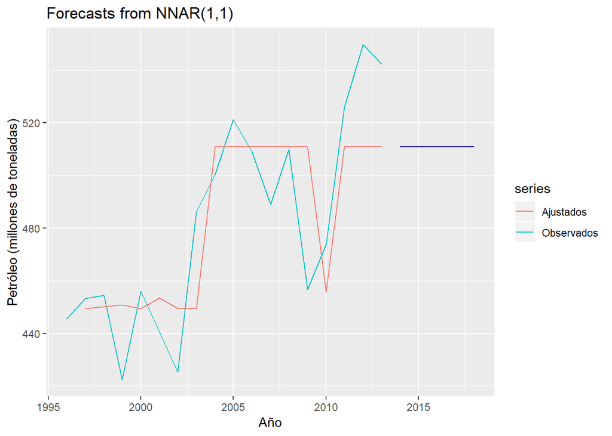

```r
mod.1 %>% forecast(h=5) %>%
  autoplot() +
  autolayer(oildata, series="Observados", PI=TRUE) +
  autolayer(fitted(mod.1), series="Ajustados") +
  ylab("Petróleo (millones de toneladas)") + xlab("Año")
```

```r
  ggtitle("Pronóstico de la venta de petroleo")
```

```
## $title
## [1] "Pronóstico de la venta de petroleo"
##
## $subtitle
## NULL
##
## attr(,"class")
## [1] "labels"
```

### Serie unemp

Veamos el desempleo en USA

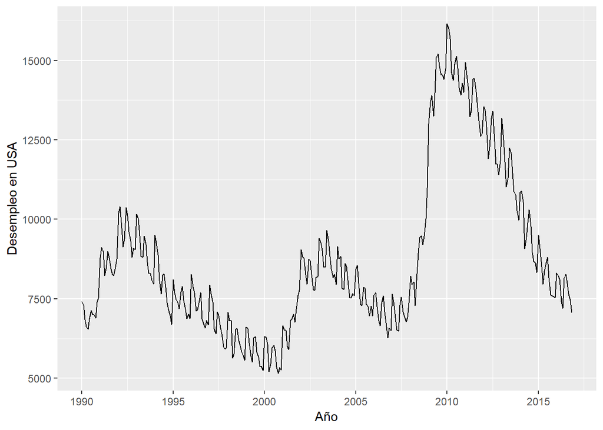

```r
autoplot(unemp) +  ylab("Desempleo en USA") + xlab("Año")
```

Estimemos un auto.arima y un RNA

```r
mod2.1 <- auto.arima(unemp)
mod2.2 <- nnetar(unemp)
(mod2.2 <- nnetar(unemp))
```

```
## Series: unemp
## Model:  NNAR(7,1,4)[12]
## Call:   nnetar(y = unemp)
##
## Average of 20 networks, each of which is
## a 8-4-1 network with 41 weights
## options were - linear output units
##
## sigma^2 estimated as 130474.1
```

```r
summary(mod2.1)
```

```
## Series: unemp
## ARIMA(2,0,2)(1,1,2)[12]
##
## Coefficients:
##             ar1         ar2         ma1        ma2       sar1        sma1
##       1.9434025  -0.9465110  -0.9730403  0.1391122  0.0602481  -0.8595401
## s.e.  0.0290458   0.0287985   0.0647444  0.0596667  0.5469097   0.5446648
##             sma2
##       -0.0000680
## s.e.   0.4561007
##
## sigma^2 estimated as 60422.22:  log likelihood=-2158.67
## AIC=4333.34   AICc=4333.82   BIC=4363.26
##
## Training set error measures:
##                       ME        RMSE         MAE           MPE        MAPE
## Training set 8.938404688 238.4700691 186.4222287 0.05463885536 2.173325616
##                      MASE           ACF1
## Training set 0.1790910142 0.007368936687
```

```r
summary(mod2.2)
```

```
##           Length Class        Mode
## x         323    ts           numeric
## m           1    -none-       numeric
## p           1    -none-       numeric
## P           1    -none-       numeric
## scalex      2    -none-       list
## size        1    -none-       numeric
## subset    323    -none-       numeric
## model      20    nnetarmodels list
## nnetargs    0    -none-       list
## fitted    323    ts           numeric
## residuals 323    ts           numeric
## lags        8    -none-       numeric
## series      1    -none-       character
## method      1    -none-       character
## call        2    -none-       call
```

Visualización de los valores observador y ajustados

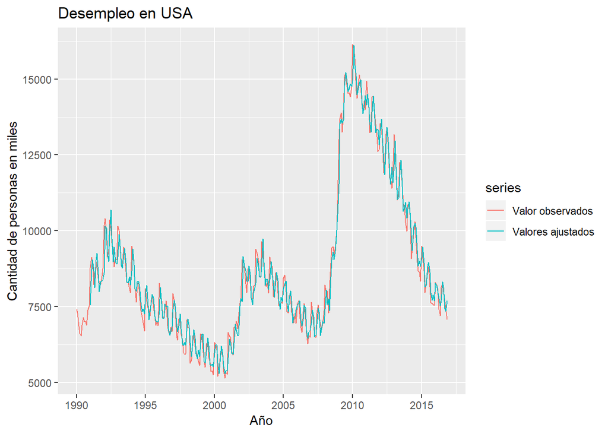

```r
autoplot(unemp, series="Valor observados") +
  autolayer(fitted(mod2.2), series="Valores ajustados") +
  ylab("Cantidad de personas en miles") + xlab("Año") +
  ggtitle("Desempleo en USA")
```

Estadísticas de rendimiento

```r
a<- round(accuracy(mod2.1),2)
b<- round(accuracy(mod2.2),2)

c<-rbind(a,b)
rownames(c)  <- c("auto.arima", "Redes Neuronales")
c
```

```
##                     ME   RMSE    MAE   MPE MAPE MASE ACF1
## auto.arima        8.94 238.47 186.42  0.05 2.17 0.18 0.01
## Redes Neuronales -1.15 361.21 263.80 -0.23 3.10 0.25 0.02
```

Valores pronosticados con intervalo de confianza

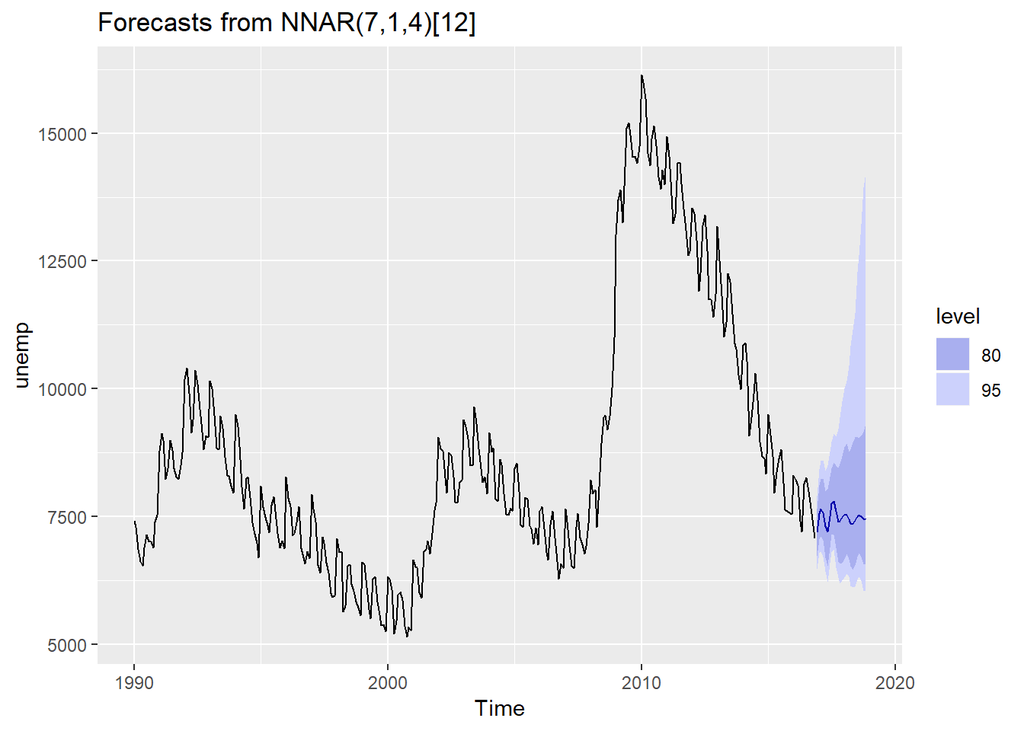

```r
fcast.2 <- forecast(mod2.2, PI=TRUE, h=24)

autoplot(fcast.2)
```

Valores pronosticados sin intervalo de confianza

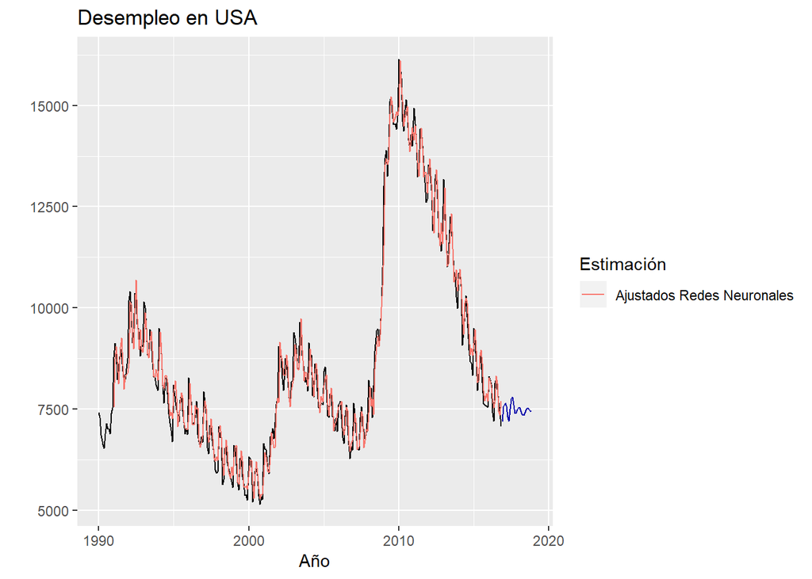

```r
mod2.2 %>% forecast(h=24) %>%
  autoplot() +
  autolayer(fitted(mod2.2), series="Ajustados Redes Neuronales") +
  ylab("") + xlab("Año") +
  ggtitle("Desempleo en USA") +
  guides(colour=guide_legend(title="Estimación"))
```

### Serie birth

Analicemos los nacimientos. Veamos la serie

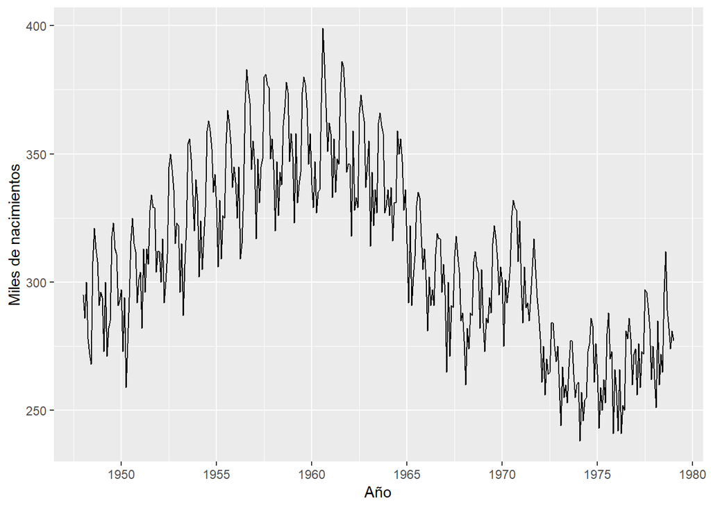

```r
autoplot(birth) +  ylab("Miles de nacimientos") + xlab("Año")
```

Estimemos un auto.arima y un RNA

```r
mod3.1 <- auto.arima(birth)
mod3.2 <- nnetar(birth, lambda = 0)
(mod3.2 <- nnetar(birth, lambda = 0))
```

```
## Series: birth
## Model:  NNAR(5,1,4)[12]
## Call:   nnetar(y = birth, lambda = 0)
##
## Average of 20 networks, each of which is
## a 6-4-1 network with 33 weights
## options were - linear output units
##
## sigma^2 estimated as 0.0008235698
```

```r
summary(mod3.1)
```

```
## Series: birth
## ARIMA(1,1,1)(1,1,1)[12]
##
## Coefficients:
##             ar1         ma1       sar1        sma1
##       0.3126791  -0.7087947  0.1058208  -0.8480974
## s.e.  0.0868435   0.0607382  0.0709891   0.0469332
##
## sigma^2 estimated as 46.04022:  log likelihood=-1204.83
## AIC=2419.66   AICc=2419.83   BIC=2439.09
##
## Training set error measures:
##                          ME        RMSE         MAE            MPE
## Training set -0.09665591797 6.628866841 5.063630827 -0.03292442666
##                    MAPE         MASE          ACF1
## Training set 1.66103279 0.5160843389 0.01128661232
```

```r
summary(mod3.2)
```

```
##           Length Class        Mode
## x         373    ts           numeric
## m           1    -none-       numeric
## p           1    -none-       numeric
## P           1    -none-       numeric
## scalex      2    -none-       list
## size        1    -none-       numeric
## lambda      1    -none-       numeric
## subset    373    -none-       numeric
## model      20    nnetarmodels list
## nnetargs    0    -none-       list
## fitted    373    ts           numeric
## residuals 373    ts           numeric
## lags        6    -none-       numeric
## series      1    -none-       character
## method      1    -none-       character
## call        3    -none-       call
```

Visualización de los valores observador y ajustados

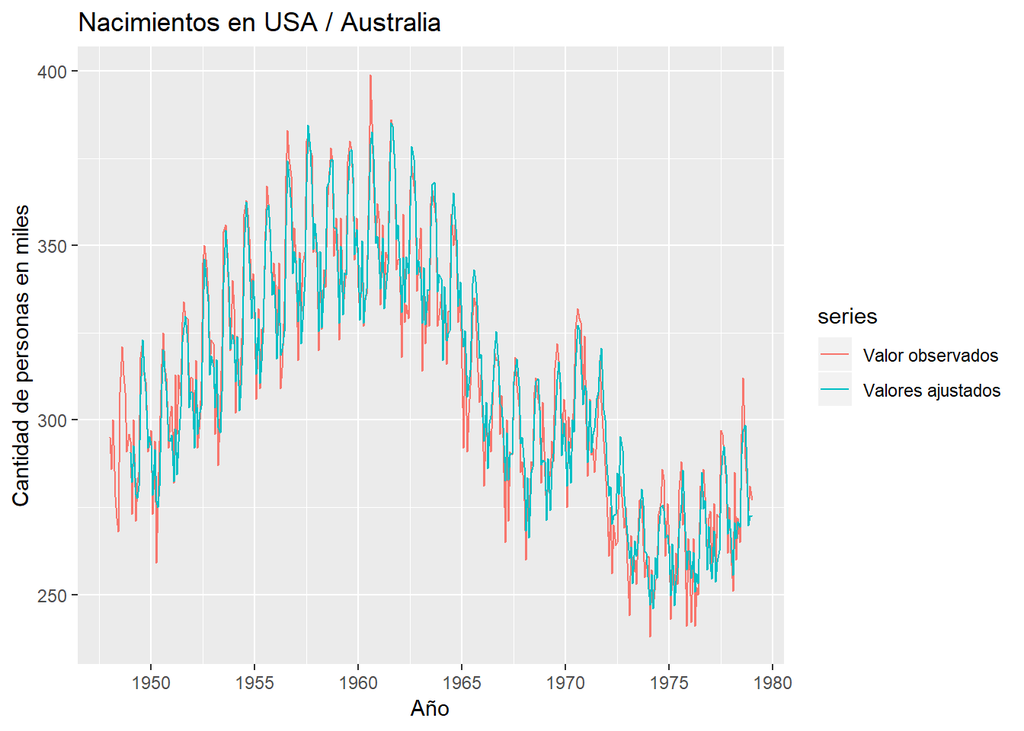

```r
autoplot(birth, series="Valor observados") +
  autolayer(fitted(mod3.2), series="Valores ajustados") +
  ylab("Cantidad de personas en miles") + xlab("Año") +
  ggtitle("Nacimientos en USA / Australia")
```

Veamos el ajuste interno

```r
a<- round(accuracy(mod3.1),2)
b<- round(accuracy(mod3.2),2)

c<-rbind(a,b)
rownames(c)  <- c("Auto.ARIMA", "Redes Neuronales Artificiales")
c
```

```
##                                  ME RMSE  MAE   MPE MAPE MASE ACF1
## Auto.ARIMA                    -0.10 6.63 5.06 -0.03 1.66 0.52 0.01
## Redes Neuronales Artificiales  0.12 7.77 6.20 -0.04 2.04 0.63 0.25
```

Valores pronosticados con intervalo de confianza

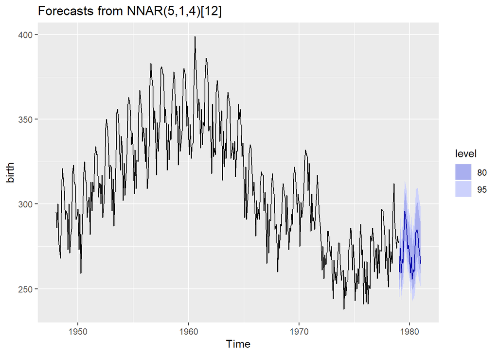

```r
fcast.3 <- forecast(mod3.2, PI=TRUE, h=24)

autoplot(fcast.3)
```

Valores pronosticados sin intervalo de confianza

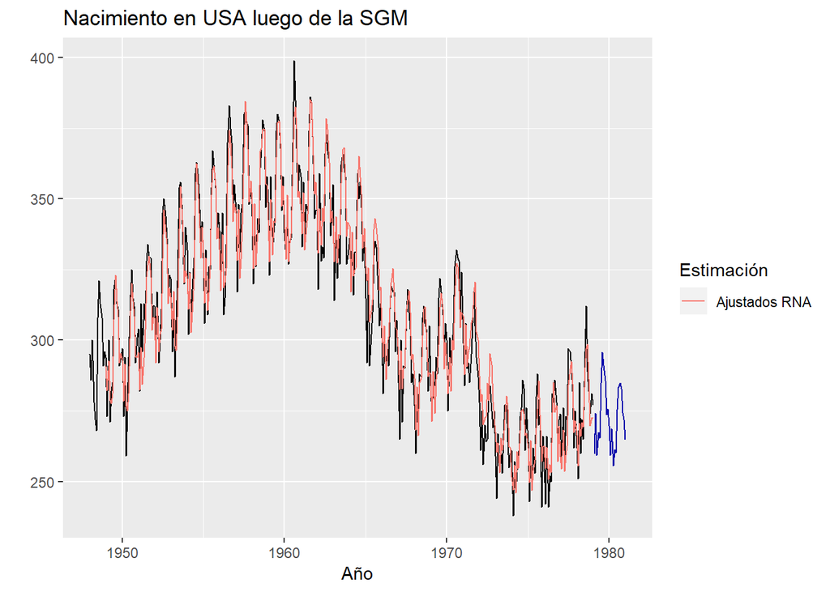

```r
mod3.2 %>% forecast(h=24) %>%
  autoplot() +
  autolayer(fitted(mod3.2), series="Ajustados RNA") +
  ylab("") + xlab("Año") +
  ggtitle("Nacimiento en USA luego de la SGM") +
  guides(colour=guide_legend(title="Estimación"))
```